# IMDB DATA

```python
import numpy as np #linear algebra
```

```python
import pandas as pd # data processing, CSV file I/O (e.g.pd.read_csv)
```

```python
import matplotlib.pyplot as plt
```

```python
import seaborn as sns
```

```python
import warnings
warnings.filterwarnings('ignore')
```

```python
data=pd.read_csv('IMDB-Movie-Data.csv')
```

1. Display Top 10 Rows of The Dataset

```python
data.head(10)
```

|  | Rank | Title | Genre | Description | Director | Actors | Year | Runtime (Minutes) | Rating | Votes | Revenue (Millions) | Metascore |
| --- | --- | --- | --- | --- | --- | --- | --- | --- | --- | --- | --- | --- |
| 0 | 1 | Guardians of the Galaxy | Action,Adventure,Sci-Fi | A group of intergalactic criminals are forced ... | James Gunn | Chris Pratt, Vin Diesel, Bradley Cooper, Zoe S... | 2014 | 121 | 8.1 | 757074 | 333.13 | 76.0 |
| 1 | 2 | Prometheus | Adventure,Mystery,Sci-Fi | Following clues to the origin of mankind, a te... | Ridley Scott | Noomi Rapace, Logan Marshall-Green, Michael Fa... | 2012 | 124 | 7.0 | 485820 | 126.46 | 65.0 |
| 2 | 3 | Split | Horror,Thriller | Three girls are kidnapped by a man with a diag... | M. Night Shyamalan | James McAvoy, Anya Taylor-Joy, Haley Lu Richar... | 2016 | 117 | 7.3 | 157606 | 138.12 | 62.0 |
| 3 | 4 | Sing | Animation,Comedy,Family | In a city of humanoid animals, a hustling thea... | Christophe Lourdelet | Matthew McConaughey,Reese Witherspoon, Seth Ma... | 2016 | 108 | 7.2 | 60545 | 270.32 | 59.0 |
| 4 | 5 | Suicide Squad | Action,Adventure,Fantasy | A secret government agency recruits some of th... | David Ayer | Will Smith, Jared Leto, Margot Robbie, Viola D... | 2016 | 123 | 6.2 | 393727 | 325.02 | 40.0 |
| 5 | 6 | The Great Wall | Action,Adventure,Fantasy | European mercenaries searching for black powde... | Yimou Zhang | Matt Damon, Tian Jing, Willem Dafoe, Andy Lau | 2016 | 103 | 6.1 | 56036 | 45.13 | 42.0 |
| 6 | 7 | La La Land | Comedy,Drama,Music | A jazz pianist falls for an aspiring actress i... | Damien Chazelle | Ryan Gosling, Emma Stone, Rosemarie DeWitt, J.... | 2016 | 128 | 8.3 | 258682 | 151.06 | 93.0 |
| 7 | 8 | Mindhorn | Comedy | A has-been actor best known for playing the ti... | Sean Foley | Essie Davis, Andrea Riseborough, Julian Barrat... | 2016 | 89 | 6.4 | 2490 | NaN | 71.0 |
| 8 | 9 | The Lost City of Z | Action,Adventure,Biography | A true-life drama, centering on British explor... | James Gray | Charlie Hunnam, Robert Pattinson, Sienna Mille... | 2016 | 141 | 7.1 | 7188 | 8.01 | 78.0 |
| 9 | 10 | Passengers | Adventure,Drama,Romance | A spacecraft traveling to a distant colony pla... | Morten Tyldum | Jennifer Lawrence, Chris Pratt, Michael Sheen,... | 2016 | 116 | 7.0 | 192177 | 100.01 | 41.0 |

2. Check Last 10 Rows of The Dataset

```python
data.tail(10)
```

|  | Rank | Title | Genre | Description | Director | Actors | Year | Runtime (Minutes) | Rating | Votes | Revenue (Millions) | Metascore |
| --- | --- | --- | --- | --- | --- | --- | --- | --- | --- | --- | --- | --- |
| 990 | 991 | Underworld: Rise of the Lycans | Action,Adventure,Fantasy | An origins story centered on the centuries-old... | Patrick Tatopoulos | Rhona Mitra, Michael Sheen, Bill Nighy, Steven... | 2009 | 92 | 6.6 | 129708 | 45.80 | 44.0 |
| 991 | 992 | Taare Zameen Par | Drama,Family,Music | An eight-year-old boy is thought to be a lazy ... | Aamir Khan | Darsheel Safary, Aamir Khan, Tanay Chheda, Sac... | 2007 | 165 | 8.5 | 102697 | 1.20 | 42.0 |
| 992 | 993 | Take Me Home Tonight | Comedy,Drama,Romance | Four years after graduation, an awkward high s... | Michael Dowse | Topher Grace, Anna Faris, Dan Fogler, Teresa P... | 2011 | 97 | 6.3 | 45419 | 6.92 | NaN |
| 993 | 994 | Resident Evil: Afterlife | Action,Adventure,Horror | While still out to destroy the evil Umbrella C... | Paul W.S. Anderson | Milla Jovovich, Ali Larter, Wentworth Miller,K... | 2010 | 97 | 5.9 | 140900 | 60.13 | 37.0 |
| 994 | 995 | Project X | Comedy | 3 high school seniors throw a birthday party t... | Nima Nourizadeh | Thomas Mann, Oliver Cooper, Jonathan Daniel Br... | 2012 | 88 | 6.7 | 164088 | 54.72 | 48.0 |
| 995 | 996 | Secret in Their Eyes | Crime,Drama,Mystery | A tight-knit team of rising investigators, alo... | Billy Ray | Chiwetel Ejiofor, Nicole Kidman, Julia Roberts... | 2015 | 111 | 6.2 | 27585 | NaN | 45.0 |
| 996 | 997 | Hostel: Part II | Horror | Three American college students studying abroa... | Eli Roth | Lauren German, Heather Matarazzo, Bijou Philli... | 2007 | 94 | 5.5 | 73152 | 17.54 | 46.0 |
| 997 | 998 | Step Up 2: The Streets | Drama,Music,Romance | Romantic sparks occur between two dance studen... | Jon M. Chu | Robert Hoffman, Briana Evigan, Cassie Ventura,... | 2008 | 98 | 6.2 | 70699 | 58.01 | 50.0 |
| 998 | 999 | Search Party | Adventure,Comedy | A pair of friends embark on a mission to reuni... | Scot Armstrong | Adam Pally, T.J. Miller, Thomas Middleditch,Sh... | 2014 | 93 | 5.6 | 4881 | NaN | 22.0 |
| 999 | 1000 | Nine Lives | Comedy,Family,Fantasy | A stuffy businessman finds himself trapped ins... | Barry Sonnenfeld | Kevin Spacey, Jennifer Garner, Robbie Amell,Ch... | 2016 | 87 | 5.3 | 12435 | 19.64 | 11.0 |

3. Find Shape of Our Dataset (Number of Rows And Number of Columns)

```python
data.shape
```

```
(1000, 12)
```

```python
print('Number of Rows',data.shape[0])
print('Number of Columns',data.shape[1])
```

```
Number of Rows 1000
Number of Columns 12
```

4. Getting Information About Our Dataset Like Total Number Rows, Total Number of Columns, Datatypes of Each Column And Memory Requirement

```python
data.info()
```

```
<class 'pandas.core.frame.DataFrame'>
RangeIndex: 1000 entries, 0 to 999
Data columns (total 12 columns):
 #   Column              Non-Null Count  Dtype
---  ------              --------------  -----
 0   Rank                1000 non-null   int64
 1   Title               1000 non-null   object
 2   Genre               1000 non-null   object
 3   Description         1000 non-null   object
 4   Director            1000 non-null   object
 5   Actors              1000 non-null   object
 6   Year                1000 non-null   int64
 7   Runtime (Minutes)   1000 non-null   int64
 8   Rating              1000 non-null   float64
 9   Votes               1000 non-null   int64
 10  Revenue (Millions)  872 non-null    float64
 11  Metascore           936 non-null    float64
dtypes: float64(3), int64(4), object(5)
memory usage: 93.9+ KB
```

5. Check Null Values In The Dataset

```python
data.isnull().sum()
```

```
Rank                    0
Title                   0
Genre                   0
Description             0
Director                0
Actors                  0
Year                    0
Runtime (Minutes)       0
Rating                  0
Votes                   0
Revenue (Millions)    128
Metascore              64
dtype: int64
```

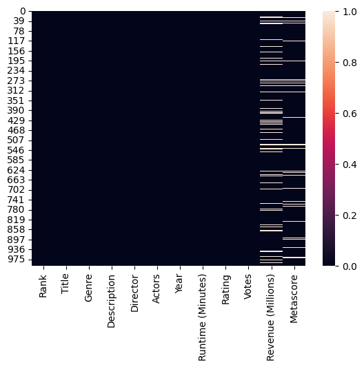

```python
sns.heatmap(data.isnull())
plt.show()
```

6. Drop All The Missing Values

```python
data = data.dropna(axis=0)
```

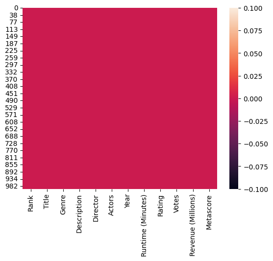

```python
sns.heatmap(data.isnull())
plt.show()
```

7. Check For Duplicate Data

```python
dup_data=data.duplicated().any()
```

```python
print("Are there any duplicated values in data?",dup_data)
```

```
Are there any duplicated values in data? False
```

```python
data=data.drop_duplicates()
data
```

|  | Rank | Title | Genre | Description | Director | Actors | Year | Runtime (Minutes) | Rating | Votes | Revenue (Millions) | Metascore |
| --- | --- | --- | --- | --- | --- | --- | --- | --- | --- | --- | --- | --- |
| 0 | 1 | Guardians of the Galaxy | Action,Adventure,Sci-Fi | A group of intergalactic criminals are forced ... | James Gunn | Chris Pratt, Vin Diesel, Bradley Cooper, Zoe S... | 2014 | 121 | 8.1 | 757074 | 333.13 | 76.0 |
| 1 | 2 | Prometheus | Adventure,Mystery,Sci-Fi | Following clues to the origin of mankind, a te... | Ridley Scott | Noomi Rapace, Logan Marshall-Green, Michael Fa... | 2012 | 124 | 7.0 | 485820 | 126.46 | 65.0 |
| 2 | 3 | Split | Horror,Thriller | Three girls are kidnapped by a man with a diag... | M. Night Shyamalan | James McAvoy, Anya Taylor-Joy, Haley Lu Richar... | 2016 | 117 | 7.3 | 157606 | 138.12 | 62.0 |
| 3 | 4 | Sing | Animation,Comedy,Family | In a city of humanoid animals, a hustling thea... | Christophe Lourdelet | Matthew McConaughey,Reese Witherspoon, Seth Ma... | 2016 | 108 | 7.2 | 60545 | 270.32 | 59.0 |
| 4 | 5 | Suicide Squad | Action,Adventure,Fantasy | A secret government agency recruits some of th... | David Ayer | Will Smith, Jared Leto, Margot Robbie, Viola D... | 2016 | 123 | 6.2 | 393727 | 325.02 | 40.0 |
| ... | ... | ... | ... | ... | ... | ... | ... | ... | ... | ... | ... | ... |
| 993 | 994 | Resident Evil: Afterlife | Action,Adventure,Horror | While still out to destroy the evil Umbrella C... | Paul W.S. Anderson | Milla Jovovich, Ali Larter, Wentworth Miller,K... | 2010 | 97 | 5.9 | 140900 | 60.13 | 37.0 |
| 994 | 995 | Project X | Comedy | 3 high school seniors throw a birthday party t... | Nima Nourizadeh | Thomas Mann, Oliver Cooper, Jonathan Daniel Br... | 2012 | 88 | 6.7 | 164088 | 54.72 | 48.0 |
| 996 | 997 | Hostel: Part II | Horror | Three American college students studying abroa... | Eli Roth | Lauren German, Heather Matarazzo, Bijou Philli... | 2007 | 94 | 5.5 | 73152 | 17.54 | 46.0 |
| 997 | 998 | Step Up 2: The Streets | Drama,Music,Romance | Romantic sparks occur between two dance studen... | Jon M. Chu | Robert Hoffman, Briana Evigan, Cassie Ventura,... | 2008 | 98 | 6.2 | 70699 | 58.01 | 50.0 |
| 999 | 1000 | Nine Lives | Comedy,Family,Fantasy | A stuffy businessman finds himself trapped ins... | Barry Sonnenfeld | Kevin Spacey, Jennifer Garner, Robbie Amell,Ch... | 2016 | 87 | 5.3 | 12435 | 19.64 | 11.0 |

838 rows × 12 columns

8. Get Overall Statistics About The DataFrame

```python
data.describe(include='all')
```

|  | Rank | Title | Genre | Description | Director | Actors | Year | Runtime (Minutes) | Rating | Votes | Revenue (Millions) | Metascore |
| --- | --- | --- | --- | --- | --- | --- | --- | --- | --- | --- | --- | --- |
| count | 838.000000 | 838 | 838 | 838 | 838 | 838 | 838.00000 | 838.000000 | 838.000000 | 8.380000e+02 | 838.000000 | 838.000000 |
| unique | NaN | 837 | 189 | 838 | 524 | 834 | NaN | NaN | NaN | NaN | NaN | NaN |
| top | NaN | The Host | Action,Adventure,Sci-Fi | A stuffy businessman finds himself trapped ins... | Ridley Scott | Daniel Radcliffe, Emma Watson, Rupert Grint, M... | NaN | NaN | NaN | NaN | NaN | NaN |
| freq | NaN | 2 | 50 | 1 | 8 | 2 | NaN | NaN | NaN | NaN | NaN | NaN |
| mean | 485.247017 | NaN | NaN | NaN | NaN | NaN | 2012.50716 | 114.638425 | 6.814320 | 1.932303e+05 | 84.564558 | 59.575179 |
| std | 286.572065 | NaN | NaN | NaN | NaN | NaN | 3.17236 | 18.470922 | 0.877754 | 1.930990e+05 | 104.520227 | 16.952416 |
| min | 1.000000 | NaN | NaN | NaN | NaN | NaN | 2006.00000 | 66.000000 | 1.900000 | 1.780000e+02 | 0.000000 | 11.000000 |
| 25% | 238.250000 | NaN | NaN | NaN | NaN | NaN | 2010.00000 | 101.000000 | 6.300000 | 6.127650e+04 | 13.967500 | 47.000000 |
| 50% | 475.500000 | NaN | NaN | NaN | NaN | NaN | 2013.00000 | 112.000000 | 6.900000 | 1.368795e+05 | 48.150000 | 60.000000 |
| 75% | 729.750000 | NaN | NaN | NaN | NaN | NaN | 2015.00000 | 124.000000 | 7.500000 | 2.710830e+05 | 116.800000 | 72.000000 |
| max | 1000.000000 | NaN | NaN | NaN | NaN | NaN | 2016.00000 | 187.000000 | 9.000000 | 1.791916e+06 | 936.630000 | 100.000000 |

9. Display Title of The Movie Having Runtime >= 180 Minutes

```python
data.columns
```

```
Index(['Rank', 'Title', 'Genre', 'Description', 'Director', 'Actors', 'Year',
       'Runtime (Minutes)', 'Rating', 'Votes', 'Revenue (Millions)',
       'Metascore'],
      dtype='object')
```

```python
data[data['Runtime (Minutes)']>=180]['Title']
```

```
82     The Wolf of Wall Street
88           The Hateful Eight
311             La vie d'Adèle
Name: Title, dtype: object
```

10. In Which Year There Was The Highest AVERAGE Voting?

```python
data.columns
```

```
Index(['Rank', 'Title', 'Genre', 'Description', 'Director', 'Actors', 'Year',
       'Runtime (Minutes)', 'Rating', 'Votes', 'Revenue (Millions)',
       'Metascore'],
      dtype='object')
```

```python
data.groupby('Year')['Votes'].mean().sort_values(ascending=False)
```

```
Year
2012    290861.483871
2006    277232.219512
2009    267180.577778
2008    266580.145833
2007    266530.704545
2010    261082.929825
2011    259254.736842
2013    225531.892857
2014    211926.881720
2015    129512.651376
2016     68437.823232
Name: Votes, dtype: float64
```

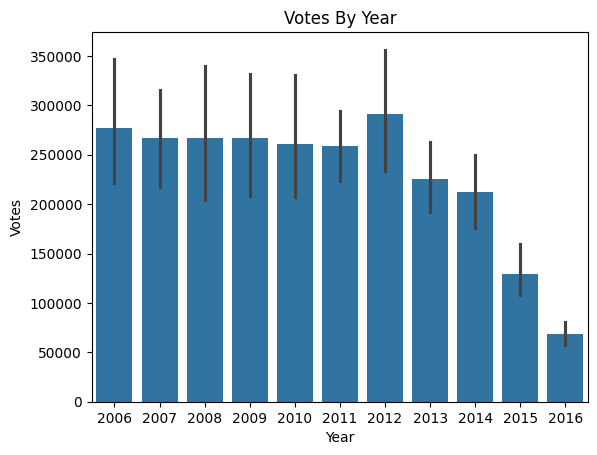

```python
sns.barplot(x='Year',y='Votes', data=data)
plt.title("Votes By Year")
plt.show()
```

11. IN WHICH YEAR THERE WAS THE HIGHEST AVERAGE REVENUE

```python
data.columns
```

```
Index(['Rank', 'Title', 'Genre', 'Description', 'Director', 'Actors', 'Year',
       'Runtime (Minutes)', 'Rating', 'Votes', 'Revenue (Millions)',
       'Metascore'],
      dtype='object')
```

```python
data.groupby('Year')['Revenue (Millions)'].mean().sort_values(ascending=False)
```

```
Year
2009    115.742000
2012    110.103065
2010    105.081579
2008     97.525417
2011     93.703333
2007     93.074091
2013     88.084643
2006     87.255610
2014     85.433656
2015     80.725596
2016     55.566111
Name: Revenue (Millions), dtype: float64
```

[figure not shown]

```python
sns.barplot(x='Year',y='Revenue (Millions)', data=data)
plt.title("Votes By Year")
plt.show()
```

12. Find The Average Rating For Each Director

```python
data.columns
```

```
Index(['Rank', 'Title', 'Genre', 'Description', 'Director', 'Actors', 'Year',
       'Runtime (Minutes)', 'Rating', 'Votes', 'Revenue (Millions)',
       'Metascore'],
      dtype='object')
```

```python
data.groupby('Director')['Rating'].mean().sort_values(ascending=False)
```

```
Director
Christopher Nolan                   8.68
Makoto Shinkai                      8.60
Olivier Nakache                     8.60
Aamir Khan                          8.50
Florian Henckel von Donnersmarck    8.50
                                    ...
Sam Taylor-Johnson                  4.10
Joey Curtis                         4.00
George Nolfi                        3.90
James Wong                          2.70
Jason Friedberg                     1.90
Name: Rating, Length: 524, dtype: float64
```

13. Display Top 10 Lengthy Movies Title

```python
data.columns
```

```
Index(['Rank', 'Title', 'Genre', 'Description', 'Director', 'Actors', 'Year',
       'Runtime (Minutes)', 'Rating', 'Votes', 'Revenue (Millions)',
       'Metascore'],
      dtype='object')
```

```python
top10_len=data.nlargest(10,'Runtime (Minutes)')[['Title','Runtime (Minutes)']]. \
set_index('Title')
```

```python
top10_len
```

| Title | Runtime (Minutes) |
| --- | --- |
| The Hateful Eight | 187 |
| The Wolf of Wall Street | 180 |
| La vie d'Adèle | 180 |
| Cloud Atlas | 172 |
| 3 Idiots | 170 |
| Interstellar | 169 |
| Pirates of the Caribbean: At World's End | 169 |
| The Hobbit: An Unexpected Journey | 169 |
| The Curious Case of Benjamin Button | 166 |
| Transformers: Age of Extinction | 165 |

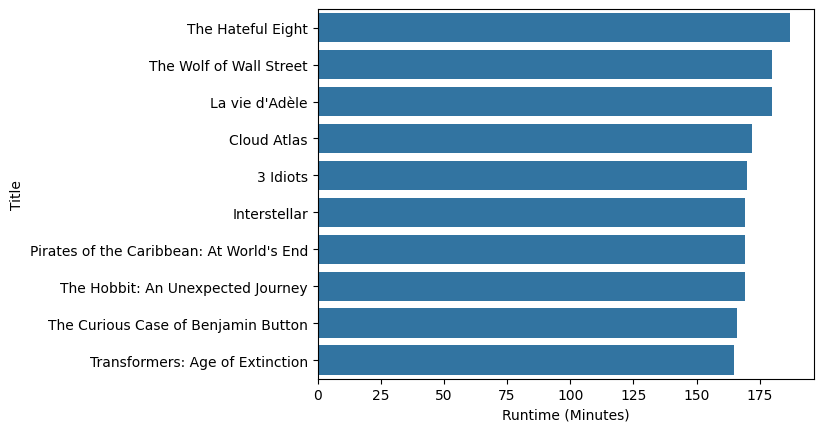

```python
sns.barplot(x='Runtime (Minutes)',y=top10_len.index,data=top10_len)
```

14. Display Number of Movies Per Year

```python
data.columns
```

```
Index(['Rank', 'Title', 'Genre', 'Description', 'Director', 'Actors', 'Year',
       'Runtime (Minutes)', 'Rating', 'Votes', 'Revenue (Millions)',
       'Metascore'],
      dtype='object')
```

```python
data['Year'].value_counts()
```

```
Year
2016    198
2015    109
2014     93
2013     84
2012     62
2010     57
2011     57
2008     48
2009     45
2007     44
2006     41
Name: count, dtype: int64
```

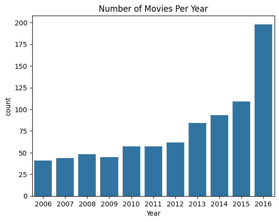

```python
sns.countplot(x='Year',data=data)
plt.title("Number of Movies Per Year")
plt.show()
```

15. Find Most Popular Movie Title (Higest Revenue)

```python
data.columns
```

```
Index(['Rank', 'Title', 'Genre', 'Description', 'Director', 'Actors', 'Year',
       'Runtime (Minutes)', 'Rating', 'Votes', 'Revenue (Millions)',
       'Metascore'],
      dtype='object')
```

```python
data[data['Revenue (Millions)'].max()==data['Revenue (Millions)']]['Title']
```

```
50    Star Wars: Episode VII - The Force Awakens
Name: Title, dtype: object
```

16. Display Top 10 Highest Rated Movie Titles And its Directors

```python
data.columns
```

```
Index(['Rank', 'Title', 'Genre', 'Description', 'Director', 'Actors', 'Year',
       'Runtime (Minutes)', 'Rating', 'Votes', 'Revenue (Millions)',
       'Metascore'],
      dtype='object')
```

```python
top10_len=data.nlargest(10,'Rating')[['Title','Rating','Director']]\
.set_index('Title')
```

```python
top10_len
```

| Title | Rating | Director |
| --- | --- | --- |
| The Dark Knight | 9.0 | Christopher Nolan |
| Inception | 8.8 | Christopher Nolan |
| Interstellar | 8.6 | Christopher Nolan |
| Kimi no na wa | 8.6 | Makoto Shinkai |
| The Intouchables | 8.6 | Olivier Nakache |
| The Prestige | 8.5 | Christopher Nolan |
| The Departed | 8.5 | Martin Scorsese |
| The Dark Knight Rises | 8.5 | Christopher Nolan |
| Whiplash | 8.5 | Damien Chazelle |
| The Lives of Others | 8.5 | Florian Henckel von Donnersmarck |

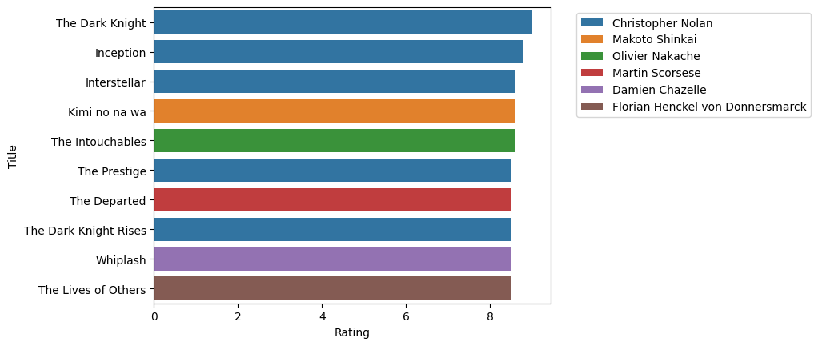

```python
sns.barplot(x='Rating',y=top10_len.index,data=top10_len,hue='Director',
            dodge=False)
plt.legend(bbox_to_anchor=(1.05,1),loc=2)
```

17. Display Top 10 Highest Revenue Movie Titles

```python
data.columns
```

```
Index(['Rank', 'Title', 'Genre', 'Description', 'Director', 'Actors', 'Year',
       'Runtime (Minutes)', 'Rating', 'Votes', 'Revenue (Millions)',
       'Metascore'],
      dtype='object')
```

```python
data.nlargest(10,'Revenue (Millions)')['Title']
```

```
50     Star Wars: Episode VII - The Force Awakens
87                                         Avatar
85                                 Jurassic World
76                                   The Avengers
54                                The Dark Knight
12                                      Rogue One
119                                  Finding Dory
94                        Avengers: Age of Ultron
124                         The Dark Knight Rises
578               The Hunger Games: Catching Fire
Name: Title, dtype: object
```

```python
top_10=data.nlargest(10,'Revenue (Millions)')[['Title','Revenue (Millions)']].\
set_index('Title')
```

```python
top_10
```

| Title | Revenue (Millions) |
| --- | --- |
| Star Wars: Episode VII - The Force Awakens | 936.63 |
| Avatar | 760.51 |
| Jurassic World | 652.18 |
| The Avengers | 623.28 |
| The Dark Knight | 533.32 |
| Rogue One | 532.17 |
| Finding Dory | 486.29 |
| Avengers: Age of Ultron | 458.99 |
| The Dark Knight Rises | 448.13 |
| The Hunger Games: Catching Fire | 424.65 |

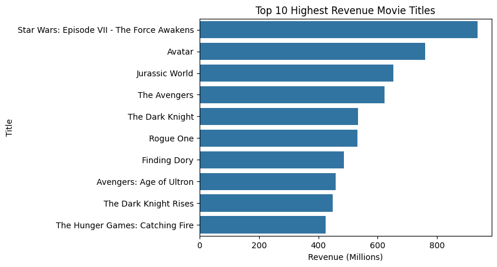

```python
sns.barplot(x='Revenue (Millions)',y=top_10.index,data=top_10)
plt.title("Top 10 Highest Revenue Movie Titles")
plt.show()
```

18. Find Average Rating of Movies Year-wise

```python
data.columns
```

```
Index(['Rank', 'Title', 'Genre', 'Description', 'Director', 'Actors', 'Year',
       'Runtime (Minutes)', 'Rating', 'Votes', 'Revenue (Millions)',
       'Metascore'],
      dtype='object')
```

```python
data.groupby('Year')['Rating'].mean().sort_values(ascending=False)
```

```
Year
2006    7.143902
2007    7.140909
2011    6.945614
2012    6.933871
2009    6.911111
2010    6.894737
2013    6.832143
2014    6.822581
2008    6.708333
2015    6.674312
2016    6.644444
Name: Rating, dtype: float64
```

19. Does Rating Affect The Revenue?

```python
data.columns
```

```
Index(['Rank', 'Title', 'Genre', 'Description', 'Director', 'Actors', 'Year',
       'Runtime (Minutes)', 'Rating', 'Votes', 'Revenue (Millions)',
       'Metascore'],
      dtype='object')
```

```python
data[data['Revenue (Millions)'].max() == data['Revenue (Millions)']]['Title']
```

```
50    Star Wars: Episode VII - The Force Awakens
Name: Title, dtype: object
```

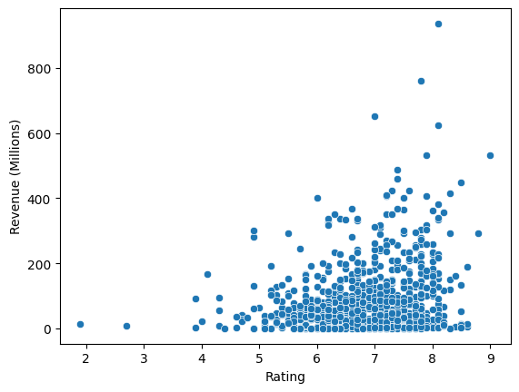

```python
sns.scatterplot(x="Rating",y="Revenue (Millions)",data=data)
```

```python
data.columns
```

```
Index(['Rank', 'Title', 'Genre', 'Description', 'Director', 'Actors', 'Year',
       'Runtime (Minutes)', 'Rating', 'Votes', 'Revenue (Millions)',
       'Metascore'],
      dtype='object')
```

```python
def rating(rating):
    if rating>=7.0:
        return 'Excellent'
    elif rating>=6.0:
        return 'Good'
    else:
        return 'Average'
```

```python
data['rating_cat']=data['Rating'].apply(rating)
```

```python
data.head()
```

|  | Rank | Title | Genre | Description | Director | Actors | Year | Runtime (Minutes) | Rating | Votes | Revenue (Millions) | Metascore | rating_cat |
| --- | --- | --- | --- | --- | --- | --- | --- | --- | --- | --- | --- | --- | --- |
| 0 | 1 | Guardians of the Galaxy | Action,Adventure,Sci-Fi | A group of intergalactic criminals are forced ... | James Gunn | Chris Pratt, Vin Diesel, Bradley Cooper, Zoe S... | 2014 | 121 | 8.1 | 757074 | 333.13 | 76.0 | Excellent |
| 1 | 2 | Prometheus | Adventure,Mystery,Sci-Fi | Following clues to the origin of mankind, a te... | Ridley Scott | Noomi Rapace, Logan Marshall-Green, Michael Fa... | 2012 | 124 | 7.0 | 485820 | 126.46 | 65.0 | Excellent |
| 2 | 3 | Split | Horror,Thriller | Three girls are kidnapped by a man with a diag... | M. Night Shyamalan | James McAvoy, Anya Taylor-Joy, Haley Lu Richar... | 2016 | 117 | 7.3 | 157606 | 138.12 | 62.0 | Excellent |
| 3 | 4 | Sing | Animation,Comedy,Family | In a city of humanoid animals, a hustling thea... | Christophe Lourdelet | Matthew McConaughey,Reese Witherspoon, Seth Ma... | 2016 | 108 | 7.2 | 60545 | 270.32 | 59.0 | Excellent |
| 4 | 5 | Suicide Squad | Action,Adventure,Fantasy | A secret government agency recruits some of th... | David Ayer | Will Smith, Jared Leto, Margot Robbie, Viola D... | 2016 | 123 | 6.2 | 393727 | 325.02 | 40.0 | Good |

21. Count Number of Action Movies

```python
data.columns
```

```
Index(['Rank', 'Title', 'Genre', 'Description', 'Director', 'Actors', 'Year',
       'Runtime (Minutes)', 'Rating', 'Votes', 'Revenue (Millions)',
       'Metascore', 'rating_cat'],
      dtype='object')
```

```python
data['Genre'].dtype
```

```
dtype('O')
```

```python
len(data[data['Genre'].str.contains('Action',case=False)])
```

```
277
```

22.Find unique values from Genre

```python
data.columns
```

```
Index(['Rank', 'Title', 'Genre', 'Description', 'Director', 'Actors', 'Year',
       'Runtime (Minutes)', 'Rating', 'Votes', 'Revenue (Millions)',
       'Metascore', 'rating_cat'],
      dtype='object')
```

```python
data['Genre']
```

```
0       Action,Adventure,Sci-Fi
1      Adventure,Mystery,Sci-Fi
2               Horror,Thriller
3       Animation,Comedy,Family
4      Action,Adventure,Fantasy
                 ...
993     Action,Adventure,Horror
994                      Comedy
996                      Horror
997         Drama,Music,Romance
999       Comedy,Family,Fantasy
Name: Genre, Length: 838, dtype: object
```

```python
list1=[]
for value in data['Genre']:
    list1.append(value.split(','))
```

```python
list1
```

[output not shown]

[output cut: 783 more lines]

[output not shown]

```python
one_d=[]
for item in list1:
    for item1 in item:
        one_d.append(item1)
```

```python
one_d
```

[output not shown]

[output cut: 946 more lines]

[output not shown]

```python
uni_list=[]
for item in one_d:
    if item not in uni_list:
        uni_list.append(item)
```

```python
uni_list
```

```
['Action',
 'Adventure',
 'Sci-Fi',
 'Mystery',
 'Horror',
 'Thriller',
 'Animation',
 'Comedy',
 'Family',
 'Fantasy',
 'Drama',
 'Music',
 'Biography',
 'Romance',
 'History',
 'Western',
 'Crime',
 'War',
 'Musical',
 'Sport']
```

23. How many filims of each Genre were Made?

```python
one_d=[]
for item in list1:
    for item1 in item:
        one_d.append(item1)
```

```python
one_d
```

[output not shown]

[output cut: 946 more lines]

[output not shown]

```python
from collections import Counter
```

```python
Counter(one_d)
```

```
Counter({'Drama': 419,
         'Action': 277,
         'Comedy': 250,
         'Adventure': 244,
         'Thriller': 148,
         'Crime': 126,
         'Romance': 120,
         'Sci-Fi': 107,
         'Fantasy': 92,
         'Horror': 87,
         'Mystery': 86,
         'Biography': 67,
         'Family': 48,
         'Animation': 45,
         'History': 25,
         'Music': 15,
         'Sport': 15,
         'War': 10,
         'Musical': 5,
         'Western': 4})
```